## The Sampling Model for Polls

To help us understand the connection between polls and what we have learned we are going to have a competition which mimics the situation a pollster faces.

We will use an urn instead of voters and to mimic the competition between pollsters for the best predictions that bring them media attention we will offer a $25 dollar prize. The challenge is to guess the spread between the proportion of blue and red beads in this urn:

[figure not shown]

Before making a prediction you can take a sample (with replacement) from the urn. To mimic the fact that running polls is expensive, it costs you $0.10 per bead you sample. So if you have a sample size of 250, and you win, you will break even as you will pay me $25 to collect your $25 prize. Your entry into the competition can be an interval. If the interval you submit contains the true proportion you get half what you paid and pass to the second phase of the competition. In the second phase the entry with the smallest interval is selected as the winner.

The `dslabs` package includes a function that shows a random draw from this urn:

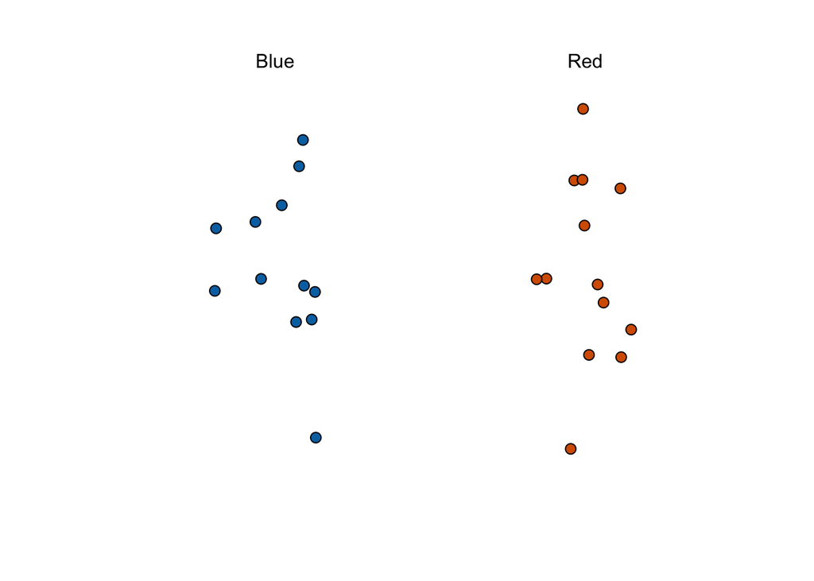

```r
library(tidyverse)
library(dslabs)
ds_theme_set()
take_poll(25)
```

Think about how you would construct your interval based on the data shown above.

We have just described a simple sampling model for opinion polls. The beads inside the urn represent the individuals that will vote on election day. Those that will vote for the republican candidate are represented with red beads and the democrats with the blue beads. For simplicity assume there are no other colors, that there are just two parties.

You can take a sample by visiting [this page.](https://dgrtwo.shinyapps.io/urn_drawing/)

Once you are ready, submit your answer at [this link.](https://docs.google.com/forms/d/e/1FAIpQLSf4vV37uFlEFfPk_MyqjM4YN_6UtVWNOE8uS5yS-CycItJfUw/viewform?usp=sf_link)

## Populations, samples, parameters and estimates

We want to predict the proportion of blue beads in the urn, let’s call this quantity $p$, which in turn tells us the proportion of red beads $1-p$, and the spread $p - (1-p)$ (the distance between $p$ and $1-p$, which simplifies to $2p - 1$.

In statistical textbooks, the beads in the urn are called the *population*. The proportion of blue beads in the population $p$ is called a *parameter*. The 25 beads we see in the plot above are called a *sample*. The task of statistical inference is to predict the parameter $p$ using the observed data in the sample.

Can we do this with the 25 observations above? It is certainly informative. For example, given we see 13 red and 12 blue, it is unlikely that $p$ > .9 or $p$ < .1. But are we ready to predict with certainty that there are more red beads than blue? We want to construct an estimate of $p$ using only the information we observe. An estimate can be thought of as a summary of the observed data that we think is informative about the parameter of interest. It seems intuitive to think that the proportion of blue beads in the sample, $0.48$ must be at least related the actual proportion $p$. But do we simply predict $p$ to be 0.48? First note that the sample proportion is a random variable. If we run the command `take_poll(25)` four times

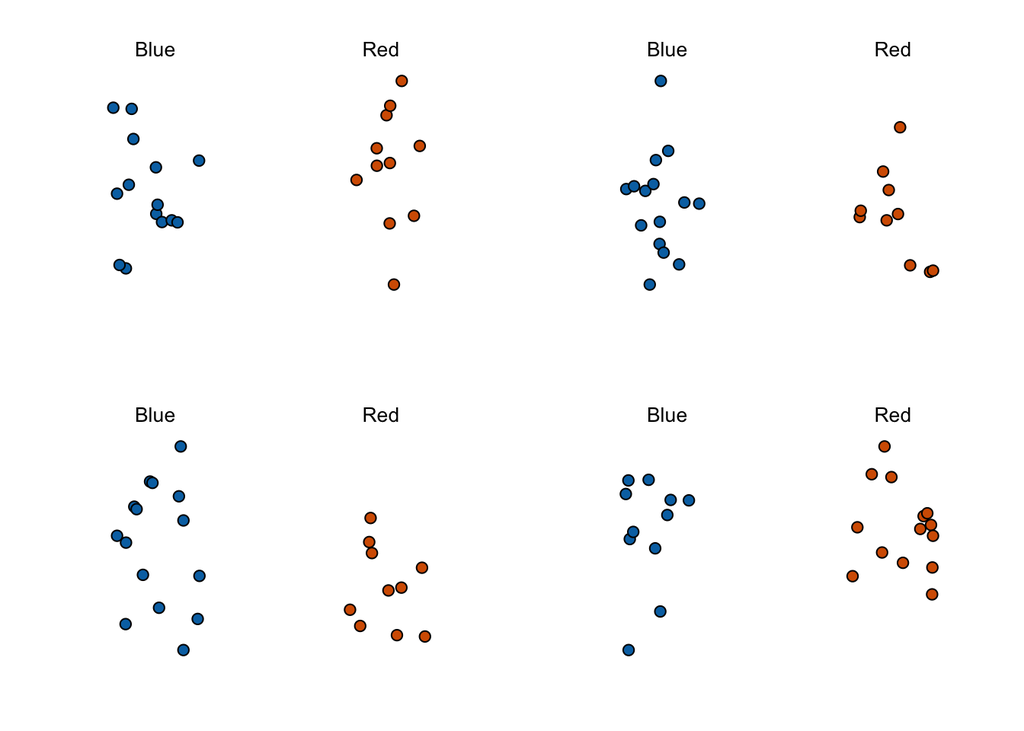

we get a different answer each time since the sample proportion is a random variable.

Note that in the four random samples we show above, the sample proportions range from 0.44 to 0.60. By describing the distribution of this random variable we will be able to gain insights into how good this estimate is and how we can make it better.

### The Sample Average

Taking an opinion poll is being modeled as taking a random sample from the urn. We are proposing the use of the proportion of blue beads in our sample as an *estimate* of the parameter $p$. Once we have this estimate we can can easily report an estimate for the spread $2p-1$, but for simplicity we will illustrate the concepts for estimating $p$. We will use our knowledge of probability to defend our use of the sample proportion and quantify how close we think it is to the population proportion $p$.

We start by defining the random variable $X=1$ if we pick a blue bead at random and $X=0$ if it is red. This implies that the population is a list of 0s and 1s. If we sample $N$ beads then the average of the draws $X_1, \dots, X_N$ is equivalent to the proportion of blue beads in our sample. This is because adding the $X$s is equivalent to counting the blue beads and dividing it by the total $N$ turns this into a proportion. We use the symbol $\bar{X}$ to represent this average. In general, in statistics text books, a bar on top of a symbol means the average.

The theory we just learned about the sum of draws becomes useful because if we know the distribution of the sum $N \bar{X}$, we know the distribution of the average $\bar{X}$ because $N$ is a non-random constant.

For simplicity, let’s assume that the draws are independent: after we see each sampled bead we return it to the urn. In this case, what do we know about the distribution of the sum of draws? First we know that the expected value of the sum of draws is $N$ times the average of the values in the urn. We know that the average of the 0s and 1s in the urn must be $p$, the proportion of blue beads.

Here we encounter an important difference with what we did in the probability module: we don’t know what is in the urn. We know there are blue and red beads but we don’t know how many of each. This is what we want to find out: we are trying to **estimate** $p$.

### Parameters

Just like we use variables to define unknowns in systems of equations, in statistical inference we define **parameters** to define unknown parts of our models. In the urn model we are using to mimic an opinion poll, we do not know the proportion of blue beads in the urn. We define the parameter $p$ to represent this quantity. Note that $p$ is the average of the urn since if we take the average of the 1s (blue) and 0s (red) we get the proportion of blue beads. Also note that our main goal is figuring out what $p$ is. We are going to *estimate this parameter*.

Note that the ideas presented here on how we estimate parameters and provide insights into how good these estimates are, extrapolate to many data science tasks. For example, we may ask what is the difference in health improvement between patients receiving treatment and a control group. We may ask what are the health effects of smoking on a population? What are the differences in racial groups of fatal shootings by police? What is the rate of change in life expectancy in the US during the last 10 years? All these questions can be framed as a task of estimating a parameter from a sample.

### Polling versus Forecasting

Before we continue let’s make an important clarification related to the practical problem of forecasting the election. If a poll is conducted four months before the election it is estimating the $p$ for that moment, not for election day. Note that the $p$ for election night might be different since people’s opinions fluctuate through time. The polls provided the night before the election tend to be the most accurate since opinions don’t change that much in a day. However, forecasters try to build tools that model how opinions vary across time and try to predict the election night result taking into consideration the fact that opinions fluctuate. We will describe some approaches for doing this in a later section.

### Properties of our estimate: Expected value and standard error

To understand how good our estimate is, we will describe the statistical properties of the random variable defined above: the sample proportion $\bar{X}$. Note that $\bar{X}$ includes the sum of independent draws so the rules we covered in the probability chapter apply.

Using what we have learned, the expected value of the sum $N\bar{X}$ is $N \times$ the average of the urn, $p$. So dividing by the non-random constant $N$ gives us that the expected value of the average $\bar{X}$ is $p$. We can write it using our mathematical notation:

$$\mbox{E}(\bar{X}) = p$$

$$\mbox{SE}(\bar{X}) = \sqrt{p(1-p)/N}$$

This result reveals the power of polls. The expected value of the sample proportion $\bar{X}$ is the parameter of interest $p$ and we can make the standard error as small as we want by increasing $N$. The law of large numbers tells us that with a large enough poll our estimate converges to $p$.

One problem is that we do not know $p$, so we can’t compute the standard error. For illustrative purposes let’s assume that $p=0.51$ and make a plot of the standard error versus the sample size $N$:

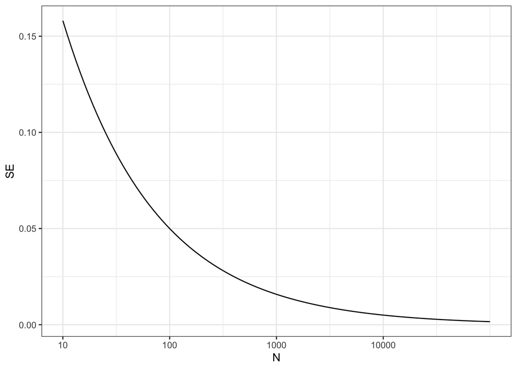

```r
sqrt(p*(1-p))/sqrt(1000)
```

```
## [1] 0.01580823
```

or 1.5 percentage points. So even with large polls, for close elections, $\bar{X}$ can lead us astray if we don’t realize it is a random variable. But we can actually say more about how close we get to $p$.